# Experimenting with the S Index

Nick Malleson

22 January, 2018 (10:03)

# Introduction

This script has code that can be used to experiment with the S Index under different conditions.

## Configuration and library loading

Configure the script here. (Un)comment or edit lines as appropriate to change the data used and the parameters for the method. (*R code not included in output*).

**Important**: the main thing to change here is the working directory (`WORKING_DIR`). Set this to the location of this Rmd file.

# Data

We use publicly-available Vancouver crime data, available [here](http://data.vancouver.ca/datacatalogue/crime-data.htm).

Data are available from: http://data.vancouver.ca/datacatalogue/crime-data-details.htm and there is a single zip file: ftp://webftp.vancouver.ca/opendata/shape/crime_shp_all_years.zip.

The script begins by downloading the data (if necessary).

```r
ZIPFILENAME <- "./data-raw/vancouver_public/crime_shp_all_years.zip"

if (!file.exists(ZIPFILENAME)) {
  print("Downloading crime data")
  download.file(url = "ftp://webftp.vancouver.ca/opendata/shape/crime_shp_all_years.zip", destfile = ZIPFILENAME)
}
```

Then read it in:

```r
# Unzip the files into the working directory
zipfile <- unzip(ZIPFILENAME)

# Read the shapefile
all.crime <- readOGR(dsn="./crime_shp_all_years", layer = "crime_shp_all_years")
# Delete the extracted file
unlink(zipfile)
unlink("crime_shp_all_years", recursive = TRUE) # a left over directory

# Assign short codes to crime types (the below throws an error about 'values must be length 1'
# if there are any crime types that aren't matched to short equivalents)
all.crime$TYPE2 <- as.factor(unlist(
  mclapply(X = all.crime$TYPE, FUN = function(t) {
    t2 <- switch(as.character(t),
          "Break and Enter Commercial" = "BNEC",
          "Break and Enter Residential/Other" = "BNER",
          "Mischief" = "MISCHIEF",
          "Other Theft" = "OTHERTHEFT",
          "Theft from Vehicle" = "TFV",
          "Theft of Bicycle" = "TOB",
          "Theft of Vehicle" = "TOV",
          "Vehicle Collision or Pedestrian Struck (with Fatality)" = "COLFAT",
          "Vehicle Collision or Pedestrian Struck (with Injury)" = "COLINJ")
})))

# Drop 2018 (not sufficient data yet)
all.crime <- all.crime[which(all.crime$YEAR<2018),]

rm(ZIPFILENAME)
```

How many different crimes are there, by year:

```r
print(xtable(table(all.crime$TYPE, all.crime$YEAR)), type="html")
```

|  | 2003 | 2004 | 2005 | 2006 | 2007 | 2008 | 2009 | 2010 | 2011 | 2012 | 2013 | 2014 | 2015 | 2016 | 2017 |
| --- | --- | --- | --- | --- | --- | --- | --- | --- | --- | --- | --- | --- | --- | --- | --- |
| Break and Enter Commercial | 3197 | 3283 | 2639 | 2844 | 2436 | 2224 | 1858 | 1657 | 1749 | 1687 | 1774 | 2244 | 2457 | 2686 | 2143 |
| Break and Enter Residential/Other | 6883 | 6538 | 5542 | 5674 | 4996 | 4432 | 3497 | 3270 | 3231 | 3311 | 3025 | 3044 | 3121 | 2995 | 2482 |
| Mischief | 6391 | 5601 | 5062 | 5184 | 4810 | 5276 | 4430 | 4506 | 4828 | 4243 | 4191 | 4518 | 4193 | 4598 | 5333 |
| Other Theft | 2582 | 2605 | 2611 | 2966 | 3024 | 3142 | 3662 | 3432 | 3562 | 3630 | 3488 | 4210 | 4679 | 5708 | 5485 |
| Theft from Vehicle | 17744 | 18204 | 16554 | 14734 | 12226 | 11298 | 10007 | 8612 | 7435 | 8097 | 8340 | 10137 | 10545 | 12816 | 12866 |
| Theft of Bicycle | 1418 | 1230 | 1416 | 1467 | 1203 | 1176 | 1641 | 1668 | 1517 | 1817 | 2034 | 2461 | 3063 | 2635 | 2170 |
| Theft of Vehicle | 6361 | 6102 | 5031 | 3682 | 3305 | 2420 | 1882 | 1467 | 1093 | 1151 | 1034 | 1290 | 1371 | 1478 | 1492 |
| Vehicle Collision or Pedestrian Struck (with Fatality) | 24 | 22 | 32 | 20 | 24 | 17 | 14 | 10 | 11 | 18 | 15 | 13 | 14 | 15 | 12 |
| Vehicle Collision or Pedestrian Struck (with Injury) | 1803 | 1868 | 1984 | 1384 | 1237 | 1185 | 1278 | 1327 | 1262 | 1474 | 1485 | 1575 | 1669 | 1699 | 1391 |

Do a graph as well, indexed to volume at the start

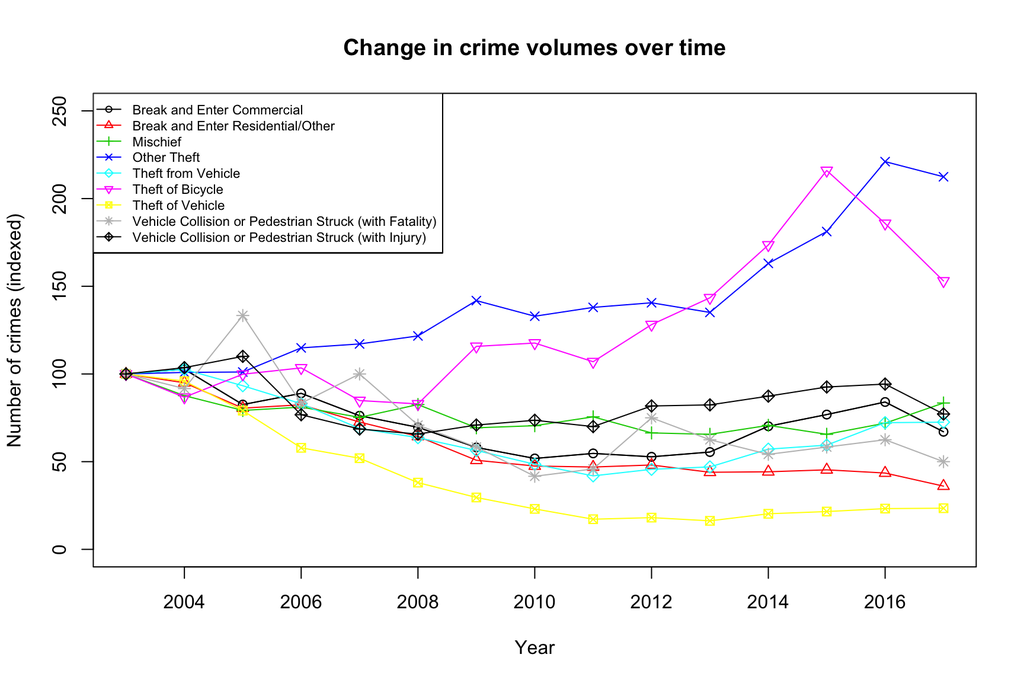

```r
crime.table <- table(all.crime$TYPE, all.crime$YEAR)
crime.types <- rownames(crime.table)
crime.years <- sapply(X = colnames(crime.table), FUN = strtoi)

for ( i in 1:length(crime.types)) {
  type <- crime.types[i]

  # Need to index
  start <- crime.table[type,1]
  yval <- 100 * ( crime.table[type,] / start)
  if (i==1) {
    plot(x=crime.years, y=yval, type='o', lty=1, pch=i, col=i, ylim=c(0,250),
         main="Change in crime volumes over time", ylab="Number of crimes (indexed)", xlab="Year"
         )
  }
  lines(x=crime.years, y=yval, type='o', lty=1, pch=i, col=i)
  legend("topleft", legend = crime.types, col=1:length(crime.types), lty=1, pch=1:length(crime.types), cex=0.7)
}
```

```r
rm(start, yval, type)
```

For context, see how many there are in total (using short names of crimes)

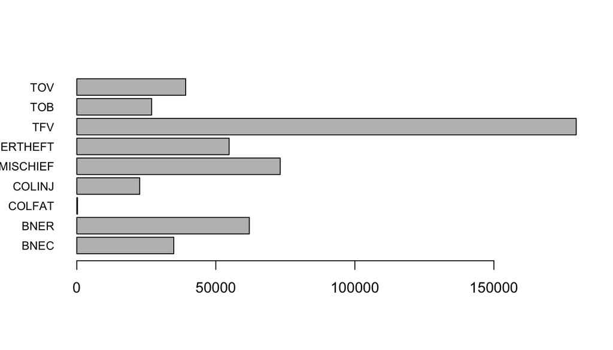

```r
barplot(rowSums(table(all.crime$TYPE2, all.crime$YEAR)
), horiz=TRUE, cex.names=0.8, las=1)
```

Finally split the big file up into different crimes and create a new variable for each crime type.

```r
# A directory for the crime data (in case it doesn't exist)
dir.create(file.path("./ROUT", "crime"), showWarnings = FALSE)

# Shorter versions of the crime types
crime.types2 <- unique(all.crime$TYPE2)

for (type in crime.types2) {
  assign(as.character(type), all.crime[all.crime$TYPE2==type,])
  # Write them as well as they can be useful later
  writeOGR(all.crime[all.crime$TYPE2==type,], dsn = "./ROUT/crime", layer = type,
           driver = "ESRI Shapefile", overwrite_layer = TRUE)
}
```

# Experiment: Sampling sizes and S Index

See what happens to the Global S Index as the relative size of the base and test datasets change. Method as follows:

1. Load one dataset (BNER will do)
2. Sample from the data
3. Run the S test, comparing the sample to the original
4. Reduce the sample size and repeat (2)
5. Graph S against the sample size (or proportion)

```r
par(mfrow=c(1,1))
van.poly <- readOGR("./data-raw/vancouver_all/areas.shp")
#Define the data to use. All BNER data at the moment.
d <- BNER

# Prepare a vector of the proportions of data to sample (e.g. 0.99, 0.98, ... 0.01)
proportion <- seq(from=0.99, to=0.01, by=-0.05)
# Do a few tests per proportion
prop <- c()
for (i in 1:10) prop <- c(prop, proportion)
proportion <- prop
rm(prop)
proportion <- sort(proportion) # Sort the proportions (e.g. 0.99, 0.99, 0.99, 0.99, 0.98, .... 0.01, 0.01.)

# Now run one test for each proportion.
# We do this in parallel, using 'mclapply' (the parallel version of 'lapply')
# This works by defining a function that samples the data, runs the test, and returns the output of sppt().
# These results are all stored in a list called 's.objects' (i.e. the objects returned by sppt())
# The equivalient 'for' loop would be like:
# s.objects <- c()
# for (p in proportion) {
#   base <- d
#   test <- d[sample(1:nrow(d), size=nrow(d)*p),] # Take a sample from d
#   s <- sppt(base_points.sp = base, test_points.sp = test, uoa.sp = van.poly)
#   s.objects <- c(s.objects, s)
# }

s.objects <- mclapply(X=proportion, FUN=function(p) {

  samp <- sample(1:nrow(d), size=nrow(d)*p) #A sample of random rows
  base <- d
  test <- d[samp,]

  s <- sppt(base_points.sp = base, test_points.sp = test, uoa.sp = van.poly)
  return(s)
})

# Now we have a list with all of the results from the sppt() function. Get a list of all of the
# global values from each test.
globalS <-        vapply(X=s.objects, FUN.VALUE = numeric(1), FUN=function(a) {a$globalS[[1]]})
globalS.robust <- vapply(X=s.objects, FUN.VALUE = numeric(1), FUN=function(a) {a$globalS.robust[[1]]})
```

Plot the results:

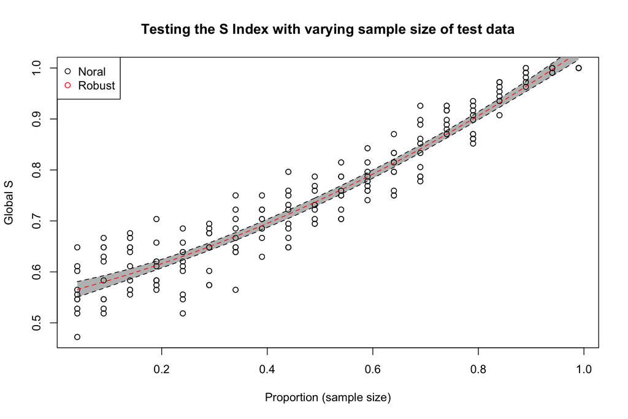

```r
# Calculate lines of best fit for S Index against proportion (using quadratic equations)
fit <-        lm ( y ~ x + I(x^2), data=data.frame("x"=proportion, "y"=globalS) )
#fit.robust <- lm ( y ~ x + I(x^2), data=data.frame("x"=proportion, "y"=globalS.robust) )

preds <-        predict(fit,        data=data.frame("x"=proportion, "y"=globalS),        interval = 'confidence')
#preds.robust <- predict(fit.robust, data=data.frame("x"=proportion, "y"=globalS.robust), interval = 'confidence')

# Plot the results (the points in this first one get copied over so needs to be redone)
plot(  x=proportion, y=unlist(globalS), main="Testing the S Index with varying sample size of test data",
       xlab="Proportion (sample size)", ylab="Global S")

polygon(c(rev(proportion), proportion), c(rev(preds[ ,3]), preds[ ,2]), col = "grey", border = NA)
#polygon(c(rev(proportion), proportion), c(rev(preds.robust[ ,3]), preds.robust[ ,2]), col = 2, border = NA)

points(x=proportion, y=unlist(globalS), col=1)
#points(x=proportion, y=unlist(globalS.robust), col=2)

# Models
lines(x=proportion, y=predict(fit), col="red", lty=2)
#lines(x=proportion, y=predict(fit.robust), col=2, lty=1)

# Confidence intervals
lines(proportion, preds[ ,3],        lty = 'dashed', col = 1)
lines(proportion, preds[ ,2],        lty = 'dashed', col = 1)
#lines(proportion, preds.robust[ ,3], lty = 'dashed', col = 2)
#lines(proportion, preds.robust[ ,2], lty = 'dashed', col = 2)

legend("topleft", legend=c("Noral", "Robust"), col=c(1,2), pch=1)
```